# Introduction to ggplot2: Points

## Part III: Aesthetic Mappings

### A) Color

#### Color Gradient for Ordinal Data

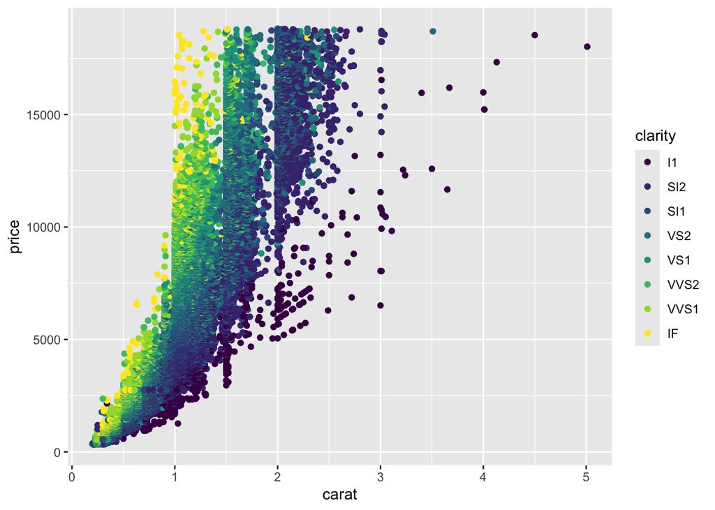

```r
# If using a categorical variable each category will have a color
ggplot(diamonds, aes(carat, price, color=clarity))+
  geom_point()
```

#### Unique colors for Nominal Data

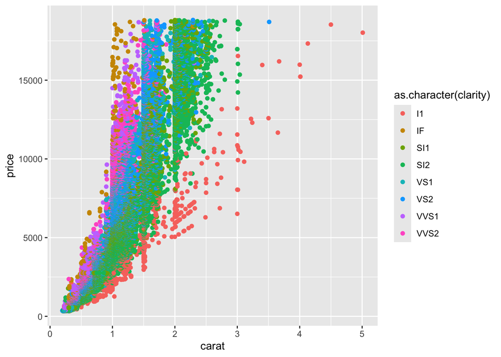

```r
# if not ordered..
ggplot(diamonds, aes(carat, price, color=as.character(clarity)))+
         geom_point()
```

#### Saturation Gradient for Numeric

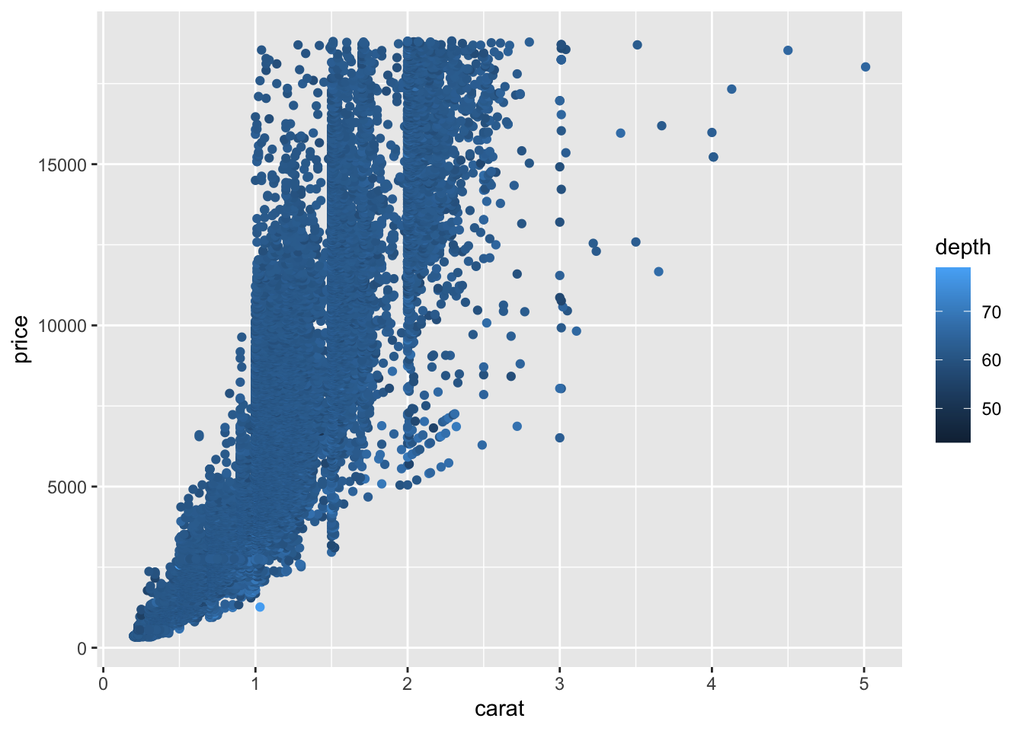

```r
# If using a numeric variable there will be a color gradient
ggplot(diamonds, aes(carat, price, color=depth))+
  geom_point()
```

You can also apply a single color to all the data points by specifying the `color` outside of the aesthetic mapping.

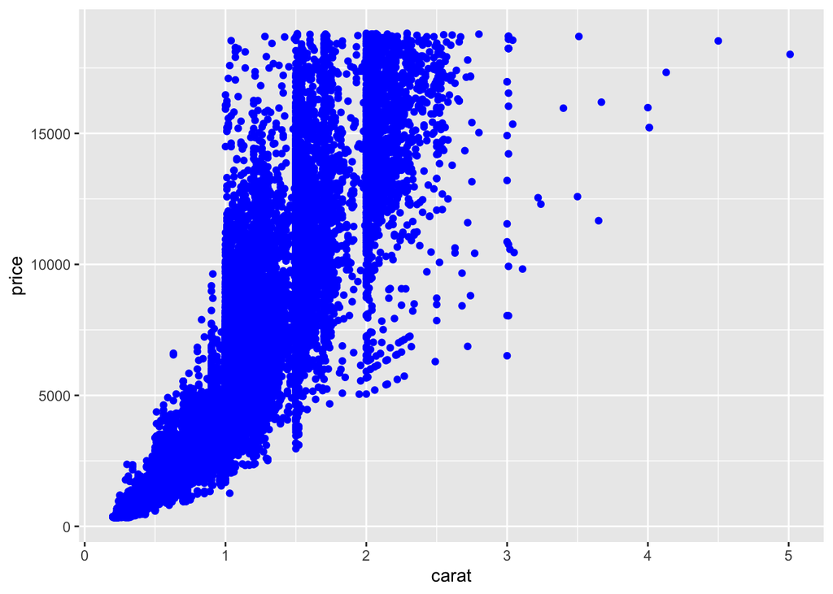

```r
ggplot(diamonds, aes(carat, price))+
  geom_point(color="blue")
```

### B) Transparency

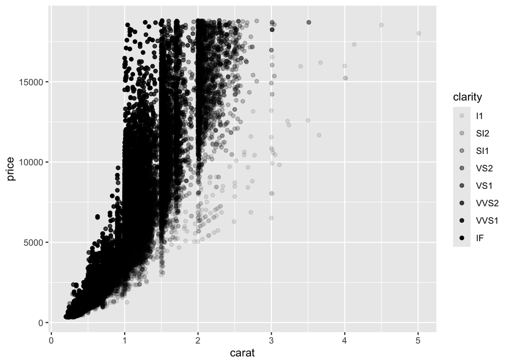

```r
ggplot(diamonds, aes(carat, price, alpha=clarity))+
  geom_point()
```

### C) Shape

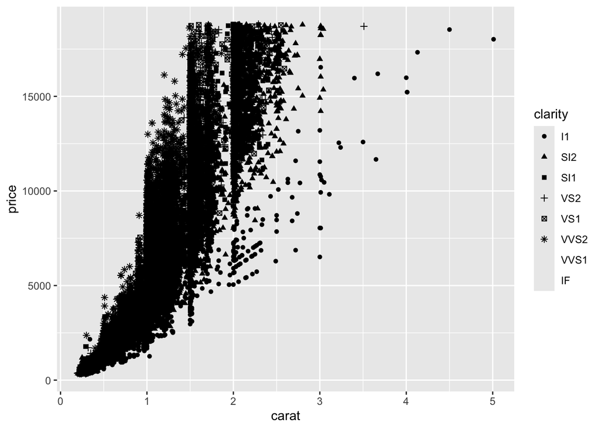

```r
ggplot(diamonds, aes(carat, price, shape=clarity))+
  geom_point()
```

### D) Size

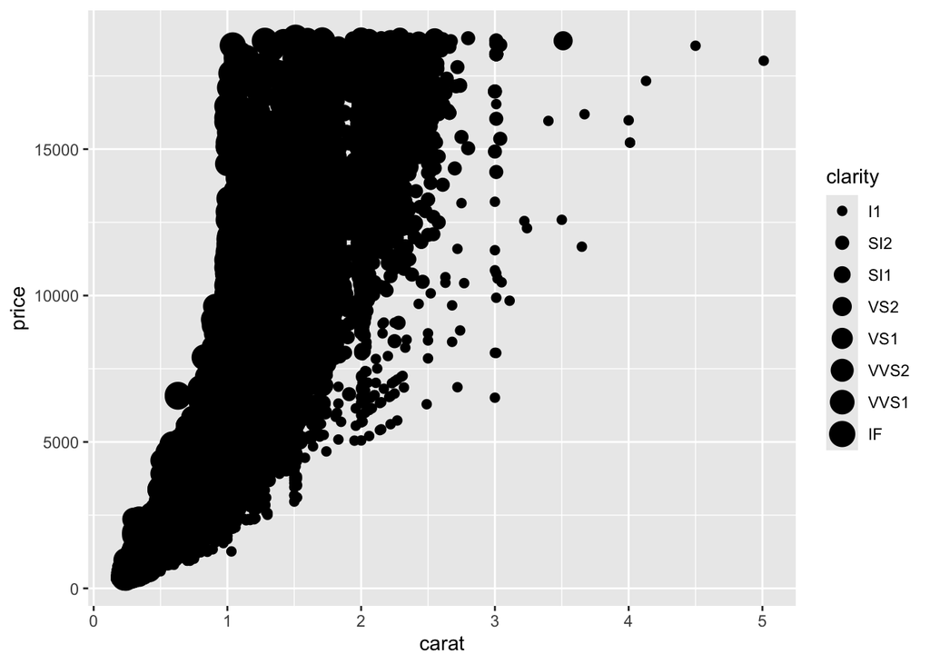

```r
ggplot(diamonds, aes(carat, price, size=clarity))+
  geom_point()
```

### It’s Your Turn! Learning by doing

1. What’s gone wrong with this code? Why are the points not blue?

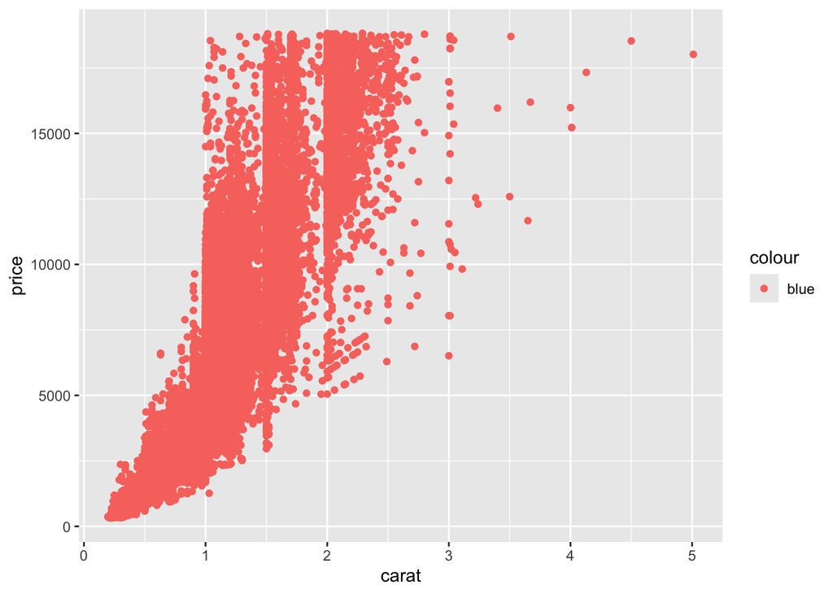

```r
ggplot(diamonds, aes(carat, price, color="blue"))+
  geom_point()
```

2. Map a continuous variable to color, size, and shape. How do these aesthetics behave differently for categorical vs. continuous variables?
3. What happens if you map the same variable to multiple aesthetics?
4. What happens if you map an aesthetic to something other than a variable name, like `aes(colour = carat < 3)`? Note, you’ll also need to specify x and y.

## Part IV: Facets

Sometimes it’s useful to look at subgroups within our data. We can do this with facets.

### `facet_wrap()`

You can specify a single discrete variable to facet by and R organize plots to fill the space.

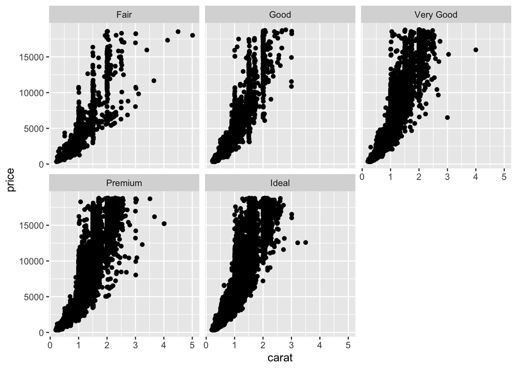

```r
ggplot(diamonds, aes(carat, price))+
  geom_point()+
  facet_wrap(~cut)
```

### `facet_grid()`

You can also create a grid of graphs. The first argument to the function specifies rows and the second columns.

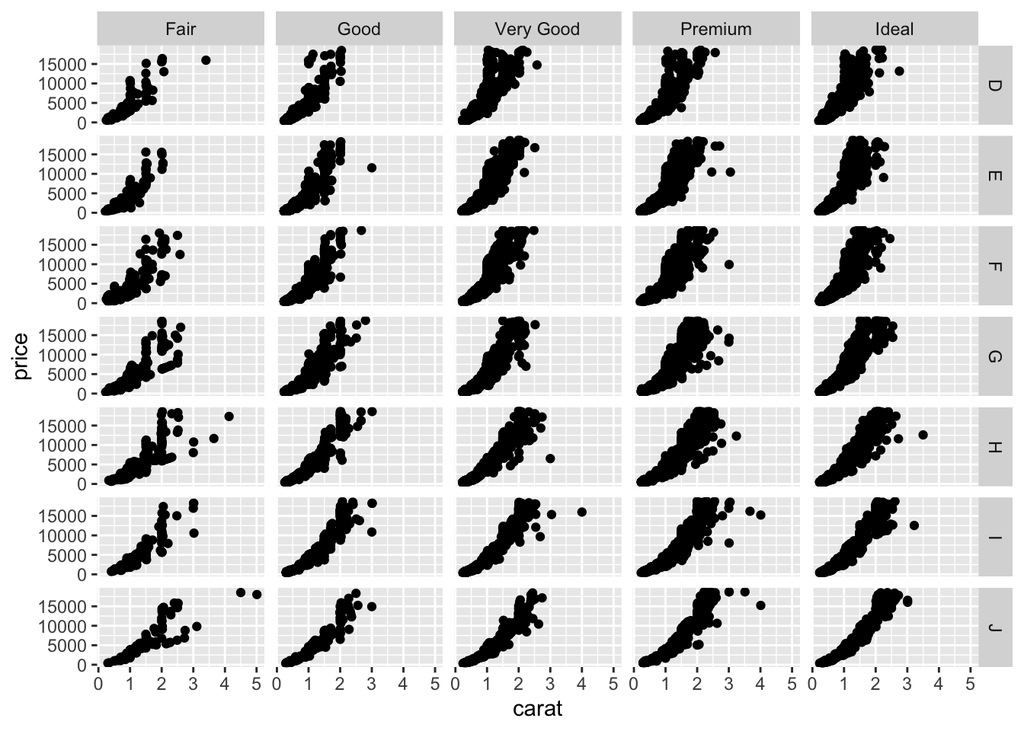

```r
## Grid
ggplot(diamonds, aes(carat, price))+
  geom_point()+
  facet_grid(color~cut)
```

If you prefer to not facet in the rows or columns dimension, use a . instead of a variable name, e.g. `+ facet_grid(. ~ color)`.

### It’s Your Turn! Learning by doing

1. What happens if you facet on a continuous variable?
2. What plots does the following code make? What does `.` do?

```r
ggplot(diamonds, aes(carat, price))+
  geom_point()+
  facet_grid(color~.)

ggplot(diamonds, aes(carat, price))+
  geom_point()+
  facet_grid(.~cut)
```

3. When using `facet_grid()` you should usually put the variable with more unique levels in the columns. Why?